# Supervised Learning

06/01/2025

# Detección de ataques con aprendizaje supervisado

El siguiente ejercicio consiste en la optmización de un modelo de Machine Learning capaz de detectar ataques a partir de logs de un firewall. Para este propósito, se realizará una prueba de concepto con una pequeña muestra de logs previamente etiquetados como tráfico normal o ataque.

## Load of the data sets

Se proporcionan los siguentes archivos:

- features.csv
- events.csv

### Events analysis/exploration

Al analizar los dos ficheros de entrada vemos que el fichero features describe los campos que aparecen en events, por lo que puede servir de base para verificar el contenido del fichero events y las tipologías de datos.

El número de observaciones en el fichero de eventos es 10000, lo que hemos considerado como un tamaño mediano de registros.

Cuando observamos los datos, vemos que algunos no se han importado en el tipo correcto y se tendrán que transformar en datos elegantes.

- srcip, dstip, proto, state, service y attack_cat deben ser factores
- Stime y Ltime son números en formato timestamp de UNIX pero se mantendrán como numéricos para facilitar el análisis
- Existen varios binarios que se han importado como entero

Además, a simple vista y dada la tipología de la información, parece que algunas de las columnas están correlacionadas.

Cuatro columnas tienen valores NA: service, ct_flw_http_mthd, is_ftp_login, ct_ftp_cmd

Finalmente se identifica que para cada observación se indica en la columna “Label” si la observación se corresponde a un ataque o es una observación normal; lo que nos permite implementar un algoritmo de aprendizaje supervisado de clasificación.

En la sección de data enrichment se mejorarán los datos para la preparación del modelo.

Comprobad el fichero features.csv incluido en la carpeta con los datos necesarios para esta practica.

### Data enrichment

Para mejorar los datos y permitir que el modelo entrene más eficientemente y sin distorsiones se van a llevar a cabo diferentes acciones:

- Preparación de los datos con los tipos adecuados (binarios, factores, etc.)
- Eliminación de NA
- Normalización de los datos númericos
- Eliminación de los datos con varianza que tiende a cero
- Eliminación de parámetros redundantes o correlacionados con otros parámetros

Así se conseguirá que el modelo se genere en menor tiempo y los resultados sean mejores.

Columnas eliminadas por tener una varianza cercana a cero: *synack, ackdat, ct_ftp_cmd, ct_dst_sport_ltm*

Columnas eliminadas por correlación: *dwin, ct_dst_src_ltm, ct_src_dport_ltm, ct_srv_dst, ct_dst_ltm, Dpkts, dloss, Ltime, sbytes*

Columnas eliminadas por combinaciones lineales: *No hay combinaciones lineales.*

## Feature engineering

Se define la Label como resultado y se establece el porcentaje de observaciones clasificadas como normales y ataque.

```
##
## ATTACK NORMAL
## 0.1251 0.8749
```

## Build model

### Create train and test data sets

Se modifica el porcentaje de datos utilizados para entrenar:

- 80% para entrenar el modelo
- 20% para testear el modelo

Se verifican además las proporciones en cada conjunto confirmando que no están balanceadas:

```
## [1] "Entreno: "
```

```
##
##    ATTACK    NORMAL
## 0.1251094 0.8748906
```

```
## [1] "Test: "
```

```
##
##    ATTACK    NORMAL
## 0.1250625 0.8749375
```

### Prepare object with training configuration (how we are gonna train the model)

En el código inicial, el modelo se entrena sin validación cruzada (method = ‘none’). Esto significa que el modelo se entrena con un único conjunto de datos de entrenamiento, lo que puede llevar a sobreajuste (overfitting) y a una menor generalización del modelo.

Cambios propuestos:

- Implementar validación cruzada para evaluar el modelo en múltiples subconjuntos de datos.
- Usar un método de validación cruzada como cv (cross-validation) con un número adecuado de folds (por ejemplo, 5 o 10).

### Train the model

Se entrena el modelo con el algoritmo original (GBM) y configurando los hiperparámetros.

Se ha probado diferentes métricas y tipos de procesamiento como PCA, pero no se ha visto mejora en los resultados.

```r
# Definir la cuadrícula de hiperparámetros
gbmGrid <- expand.grid(
   n.trees = c(150, 300, 550),     # Número de árboles
   interaction.depth = c(3, 5, 7),   # Profundidad de los árboles
   shrinkage = c(0.01,0.1),         # Tasa de aprendizaje
   n.minobsinnode = 10        # Mínimo de observaciones en nodos terminales
)

# Entrenar el modelo con la cuadrícula de hiperparámetros
objModel2 <- caret::train(
  trainDF[, predictorsNames],
  trainDF[, outcomeName],
  method = 'gbm',
  trControl = objControl2,
  metric = "ROC",
  preProc = c("scale", "center"),
  tuneGrid = gbmGrid  # Usar la cuadrícula de hiperparámetros
)
```

### Test model

Se realiza el cálculo de la muestra de test.

## Evaluate model

```
##  Accuracy     Kappa
## 0.9939970 0.9724751
```

```r
# probabilites
predictions2 <- predict(object = objModel2, testDF[,predictorsNames], type = 'prob')
auc <- pROC::roc(ifelse(testDF[,outcomeName] == "ATTACK",1,0), predictions2[[2]])
print(auc$auc)
```

```
## Area under the curve: 0.9997
```

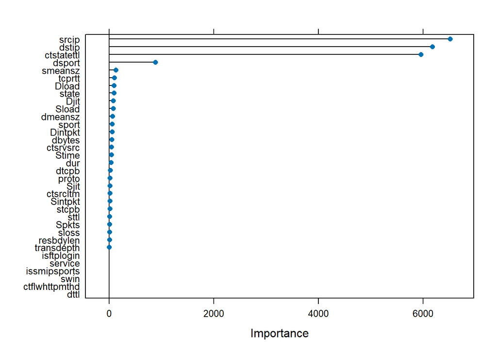

```r
plot(caret::varImp(objModel2, scale = F))
```

## Conclusiones

Para incrementar la precisión del modelo se han realizado los cambios siguientes:

1. Se han analizado los datos y se han enriquecido, convirtiendolos a datos elegantes: convirtiendolos a tipos adecuados, eliminando NAs y eliminando columnas redundantes o con poca variabilidad.
2. Se ha cambiado el % de observaciones dedicadas al entreno incrementando el valor hasta el 80%
3. Se ha verificado que el algorimo GGBM (Gradient Boosting Machine) era adecuado para el ejercicio de clasificación que se quería hacer y se han configurado los hiperparámetros